# Case Study 1

Group from MSDS 6306 - 404: Jethin Abraham, Daniel Higdon, Mustafa Sakarwala, and Keyue Wang

3/8/2017

# Introduction

The puropose of our project is to demonstrate, and understand, how the annual GDP (Gross Domestic Product) of countries around the globe compares to the their income grouping according to The World Bank. Throughout the project we will utilize two World Bank data sets:

1. GDP of 190 countries in 2012
2. Educational data on 235 various countries

The project will take readers through the analysis step-by-step, from downloading of the data to the final analysis. We will conclude with our findings of the analysis.

Before getting started, you should make sure you have installed and loaded the ggplot2, and dplyr packages into your R workspace. We will use functions from both packages through the project.

```r
if (!require("dplyr")) {
  install.packages("dplyr", repos="http://cran.rstudio.com/")
}
```

```r
library(dplyr)
if (!require("ggplot2")) {
  install.packages("ggplot2", repos="http://cran.rstudio.com/")
}
library(ggplot2)

#Set your working directory
#setwd("C:/Users/ThomasWang/Desktop/Doing Data Science/Case Study 1/CaseStudy1/CaseStudy1")
```

## Step 1: Downloading the data

We will be downloading our data from the provided URLs and read them into the variables GDP and econ. After analyzing the data, we also used this step to skip the first 3 rows of the GDP data because they are irrelevant to our analysis. Next we remove the sub-totals and totals at the bottom of the data set, as they will not be used in this analysis. In addition, we replaced empty values with ‘NA’ for both the GDP and econ data.

```r
#download and read the data

GDP <- read.csv('https://d396qusza40orc.cloudfront.net/getdata%2Fdata%2FGDP.csv ' ,skip = 3 ,nrows=236,na.strings=c("","NA"))
econ <- read.csv('https://d396qusza40orc.cloudfront.net/getdata%2Fdata%2FEDSTATS_Country.csv',na.strings=c("","NA"))
```

## Step 2: Cleaning the data

Now that we have our data, a quick view of it shows that the GDP data set is not clean. First, we rename each field to something that makes more sense (“CountryCode”, “Rank”, “Country”, and “USD”). We will then sum the number of ‘NA’ that we find in our CountryCode column into the variable NA_Count. We see that there are a total of 8 counts of ‘NA’ in the CountryCode column. Finally, we have a remaining problem. R has saved the Rank as USD columns as factors, not numbers. We are going to do math on these columns later in the analysis, so we’ll go ahead and change them to numeric in the last two lines of code.

```r
#Cleaning the data, deleting unnecessary rows and columns
names(GDP) <- c('CountryCode','Rank','x','Country','USD')

#Subsetting columns of our interest
Clean_GDP_NA <- subset(GDP,select = c('CountryCode','Rank','Country','USD'))

#Creating a function to check for NA is rows
row.has.na <- apply(Clean_GDP_NA, 1, function(x){any(is.na(x))})

#Removing the rows that are NULL and getitng a clean set of data
Clean_GDP <- Clean_GDP_NA[!row.has.na,]

#Count the number of missing values
NA_Count <- sum(is.na(Clean_GDP_NA$CountryCode))
NA_Count
```

```
## [1] 8
```

```r
#making Rank and GDP numeric
Clean_GDP$Rank<-as.numeric(as.character((Clean_GDP$Rank)))
Clean_GDP$USD<-as.numeric(gsub(",","",Clean_GDP$USD))
```

## Step 3: Merge the data sets (Question 1)

After merging the data sets you’ll notice a warning message that NAs have been duplicated. This is again caused by R saving the Rank and USD fields as factors rather than the numeric data type. We’ll fix it with the second and third line of code, similar to how we did in step two.

```r
#Merging the two datasets
Comb_data<-merge(Clean_GDP,econ,by="CountryCode")
#Making Rank and USD numeric
Comb_data$Rank<-as.numeric(as.character(Comb_data$Rank))
Comb_data$USD<-as.numeric(gsub(",","",Comb_data$USD))

#Q1
summary(Clean_GDP)
```

```
##   CountryCode       Rank                       Country
##  ABW    :  1   Min.   :  1.00   Afghanistan        :  1
##  AFG    :  1   1st Qu.: 48.25   Albania            :  1
##  AGO    :  1   Median : 95.50   Algeria            :  1
##  ALB    :  1   Mean   : 95.49   Angola             :  1
##  ARE    :  1   3rd Qu.:142.75   Antigua and Barbuda:  1
##  ARG    :  1   Max.   :190.00   Argentina          :  1
##  (Other):184                    (Other)            :184
##       USD
##  Min.   :      40
##  1st Qu.:    7005
##  Median :   27638
##  Mean   :  377652
##  3rd Qu.:  205289
##  Max.   :16244600
##
```

```r
summary(Comb_data)
```

```
##   CountryCode       Rank                       Country
##  ABW    :  1   Min.   :  1.00   Afghanistan        :  1
##  AFG    :  1   1st Qu.: 48.00   Albania            :  1
##  AGO    :  1   Median : 95.00   Algeria            :  1
##  ALB    :  1   Mean   : 95.31   Angola             :  1
##  ARE    :  1   3rd Qu.:143.00   Antigua and Barbuda:  1
##  ARG    :  1   Max.   :190.00   Argentina          :  1
##  (Other):183                    (Other)            :183
##       USD                            Long.Name
##  Min.   :      40   Antigua and Barbuda   :  1
##  1st Qu.:    6972   Arab Republic of Egypt:  1
##  Median :   28242   Argentine Republic    :  1
##  Mean   :  379597   Aruba                 :  1
##  3rd Qu.:  205789   Barbados              :  1
##  Max.   :16244600   Belize                :  1
##                     (Other)               :183
##                Income.Group                        Region
##  High income: nonOECD:23    East Asia & Pacific       :29
##  High income: OECD   :30    Europe & Central Asia     :50
##  Low income          :37    Latin America & Caribbean :35
##  Lower middle income :54    Middle East & North Africa:18
##  Upper middle income :45    North America             : 3
##                             South Asia                : 8
##                             Sub-Saharan Africa        :46
##  Lending.category    Other.groups               Currency.Unit
##  Blend:16         Euro area: 16   Euro                 : 18
##  IBRD :62         HIPC     : 39   CFA franc            : 14
##  IDA  :60         NA's     :134   U.S. dollar          :  8
##  NA's :51                         East Caribbean dollar:  6
##                                   Australian dollar    :  3
##                                   Afghan afghani       :  1
##                                   (Other)              :139
##  Latest.population.census Latest.household.survey
##  2001   :45               MICS, 2006:21
##  2000   :30               DHS, 2005 : 7
##  2002   :21               DHS, 2007 : 6
##  2006   :14               MICS, 2005: 6
##  2004   :12               DHS, 2008 : 5
##  (Other):66               (Other)   :71
##  NA's   : 1               NA's      :73
```

[output cut: 81 more lines]

```
##  AE     :  1   AE     :  1   Afghanistan        :  1
##  AF     :  1   AF     :  1   Albania            :  1
##  AG     :  1   AG     :  1   Algeria            :  1
##  AL     :  1   AL     :  1   Angola             :  1
##  AM     :  1   AM     :  1   Antigua and Barbuda:  1
##  (Other):182   (Other):183   Argentina          :  1
##  NA's   :  2   NA's   :  1   (Other)            :183
##                Short.Name
##  Afghanistan        :  1
##  Albania            :  1
##  Algeria            :  1
##  Angola             :  1
##  Antigua and Barbuda:  1
##  Argentina          :  1
##  (Other)            :183
```

```r
#189 of 190 IDs match
```

Looking at the output of the summary() functions on each data set, we see (from the length) that the Clean_GDP data set had 190 records, but the merged data set (Comb_data) has only 189. This tells us that only 189 of the IDs matched.

## Step 4: Sort the data in ascending order (Question 2)

After sorting the data we can see that St. Kitts and Nevis has the 13th smallest GDP. Note that St. Kitts and Nevis has the same GDP as Grenada, but due to sorting rules, St. Kitts and Nevis shows up as the 13th record returned.

```r
#sorting
Comb_data<-Comb_data[order(Comb_data$USD,decreasing=FALSE),]
#Q2
Comb_data[13,3]
```

```
## [1] St. Kitts and Nevis
## 228 Levels:   East Asia & Pacific   Euro area ... Zimbabwe
```

## Step 5: Determine the average GDP rankings for the “High income: OECD” and “High income nonOECD” groups (Question 3)

What if we wanted to know the average GDP rank for “High income: OECD” countries and the “High income: nonOECD” countries? We could use the subset function to limit our data for only countries falling into those categories, and then take the mean of the rank column:

```r
#Q3
Hi_OECD<-subset(Comb_data,Income.Group=="High income: OECD",select=c(Rank,CountryCode,USD,Income.Group))
mean(Hi_OECD$Rank)
```

```
## [1] 32.96667
```

```r
Hi_nonOECD<-subset(Comb_data,Income.Group=="High income: nonOECD",select=c(Rank,CountryCode,USD,Income.Group))
mean(Hi_nonOECD$Rank)
```

```
## [1] 91.91304
```

After doing so, we can see that the High income: OECD countries have a higher average GDP ranking of 32.9667 vs. 91.91304.

## Step 6: Plot, and color code based on income group, the GDP for all of the countries (Question 4)

Charts can often help us understand a large amount of data, very quickly. To accomplish that, we’ll plot the GDP in USD on the y-axis, and provide a column for each country on the x-axis. To make the chart even more helpful, we will color code the columns by income group, and put the y-axis on a log10 scale so that the outliers do not overwhelm the other data points:

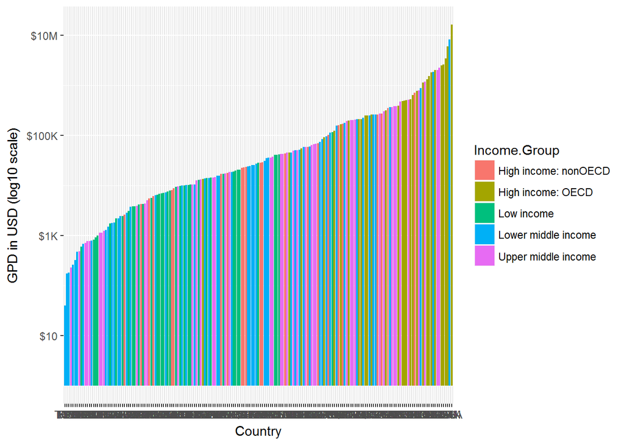

```r
#Q4
Comb_data$CountryCode<-factor(Comb_data$CountryCode,levels=Comb_data[order(Comb_data$USD,decreasing=FALSE),"CountryCode"])
qplot(CountryCode,USD,data=Comb_data,fill=Income.Group,geom="col")+scale_y_log10(labels=c("$0","$10","$1K","$100K","$10M"))+labs(x="Country",y="GPD in USD (log10 scale)")
```

## Step 7: Break the country ranks (by GDP) in to quantiles (Question 5)

Finally, we want to know how many countries are considered to be in the Lower middle income group, but in the top quantile of countries in terms of GDP. To accomplish this we’ll create a new field called “quantile” and use the cut function to divide our data into quantiles. Then we’ll subset the data to only those countires where “Income.Group” is equal to “Lower middle income” and their GDP rank is in the first quantile:

```r
#Q5
Comb_data$quantile<-with(Comb_data,cut(Rank,breaks=quantile(Rank, probs=seq(0,1,by=0.2),na.rm=TRUE),include.lowest=TRUE))
IncvsGDP<-Comb_data[(Comb_data$Income.Group=="Lower middle income") & (Comb_data$quantile=="[1,38.6]"),c("Rank","CountryCode","Income.Group","quantile")]
str(IncvsGDP)
```

```
## 'data.frame':    5 obs. of  4 variables:
##  $ Rank        : num  38 31 16 10 2
##  $ CountryCode : Factor w/ 189 levels "TUV","KIR","MHL",..: 152 159 174 180 188
##  $ Income.Group: Factor w/ 5 levels "High income: nonOECD",..: 4 4 4 4 4
##  $ quantile    : Factor w/ 5 levels "[1,38.6]","(38.6,76.2]",..: 1 1 1 1 1
```